# xv20220623_CCD_preprocessing

x.vergara

2022-06-24

In this document, I will go over different calculations of epistasis.4 different workflows: First decision is whether to use log2 MMEJscore or MMEJscore Second decision is comparing slopes or statistic differences between WT vs. KO slopes

```r
knitr::opts_chunk$set(root.dir = '/DATA/home/x.vergara/XV_P3_ChromDSBScreen/xv_CRISPR_screen_figures/rmarkdown/xv20210920_paper_scripts/short_version/knit_html/')

StartTime <-Sys.time()
library(knitr)

# 8-digit Date tag:
Date <- substr(gsub("-","",Sys.time()),1,8)

#Change in.dir accordingly
in.dir <- "/DATA/home/x.vergara/XV_P3_ChromDSBScreen/xv_CRISPR_screen_figures/"

#Check if output contain datetag
saveRDS_proof <- function(object, file) {
  if (grepl(Date, file) == T) {
    saveRDS(object, file)
  }
  else {
    print("Incorrect datetag!")
  }
}
```

# Libraries

```r
# libraries:
library(tidyverse)
library(reshape2)
library(broom)
library(dendextend)
library(pls)
library(broom)
library(stats)
```

# Import data tables

#This is a analysis pipeline to study chromatin context dependencies (CCD) #This is a proposal to get to a final version where we can infer statistical significance from the data

#I am currently working on these steps: 1- log2 MMEJ:NHEJ ratio calculation 2- Filter based on z-score of this data: Filter genes that have 1 significant IPR (z-score > 1.95) in at least 2 replicates. 3- Compute log2 MMEJ:NHEJ fold changes based on WT values: Compare with WT samples (This shows that data is reproducible and R are better for KO than WT) 4- Compute CCDs with WT wells (random CCDs) and KO samples A- Table with mean CCDs B- Table with all CCDs per replicate 5- Test for non-random CCDs (KS test, I could even use the WT from the other screen, it won’t change much). These are the interactions that matter and they correlate decently between replicates A- non-random genes based on mean CCDs B- non-random genes based on all CCDs per replicate

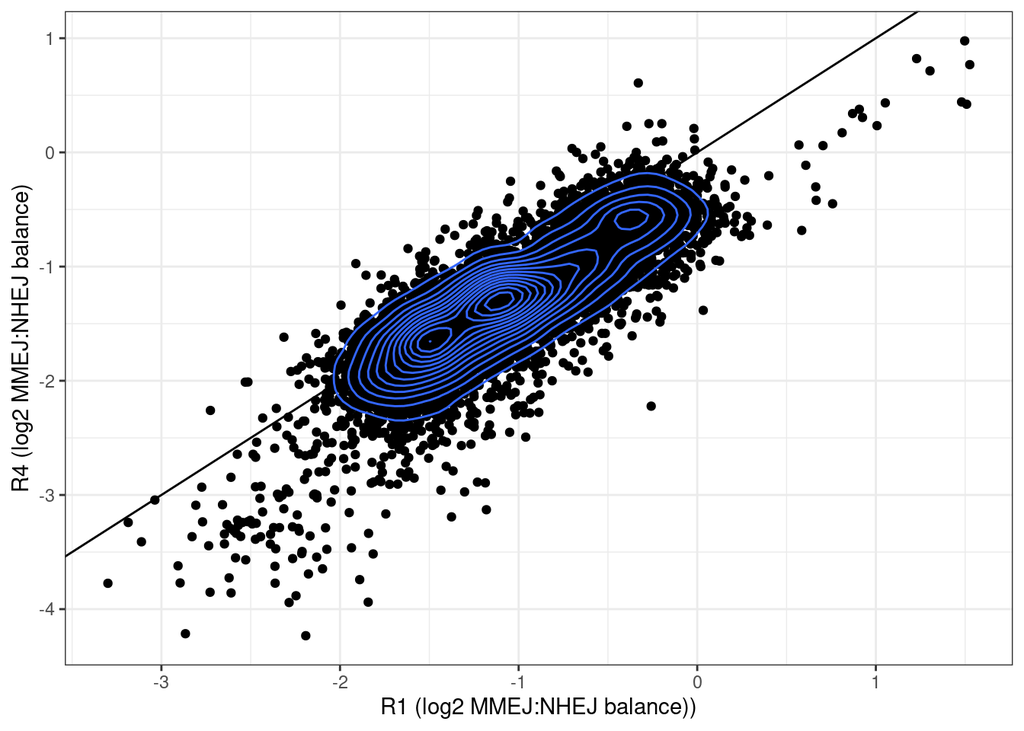

```r
#Compute the log2 MMEJ:NHEJ balance: Initial dataset
log2.ratio.screen.detail.ddr <- ddr.screen.all.sel %>% dplyr::select(t.rep, MMEJNHEJratio,library, gene,barcode,sample,well,plate) %>% mutate(log2ratio = log2(MMEJNHEJratio))

#dcast data table for plotting reproducibility of the ratio
balance.ratio.list <- log2.ratio.screen.detail.ddr %>% reshape2::dcast(gene + library + barcode + sample + well + plate ~ t.rep, value.var = "log2ratio")

# Plot reproducibility DNA_repair library
ggplot(balance.ratio.list %>% filter(library == "DNA_repair")) + geom_point(aes(R1,R4)) + xlab("R1 (log2 MMEJ:NHEJ balance))") + ylab("R4 (log2 MMEJ:NHEJ balance)") + geom_abline() + theme_bw() + geom_density2d(aes(R1,R4))
```

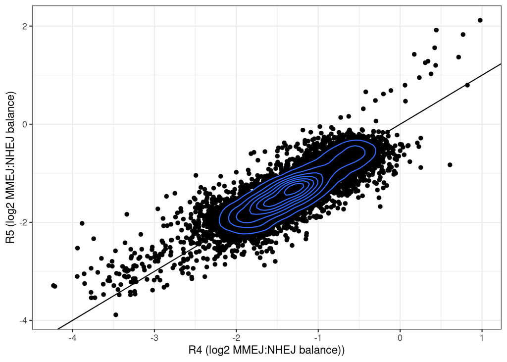

```r
ggplot(balance.ratio.list %>% filter(library == "DNA_repair")) + geom_point(aes(R4,R5)) + xlab("R4 (log2 MMEJ:NHEJ balance))") + ylab("R5 (log2 MMEJ:NHEJ balance)") + geom_abline() + theme_bw()  + geom_density2d(aes(R4,R5))
```

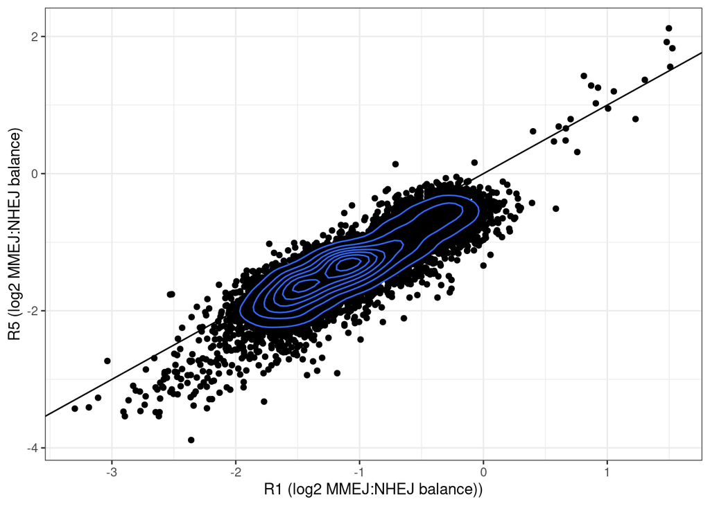

```r
ggplot(balance.ratio.list %>% filter(library == "DNA_repair")) + geom_point(aes(R1,R5)) + xlab("R1 (log2 MMEJ:NHEJ balance))") + ylab("R5 (log2 MMEJ:NHEJ balance)") + geom_abline() + theme_bw()  + geom_density2d(aes(R1,R5))
```

```r
#Extract non-targetting samples from this dataset
wt.set.ratio <- filter(log2.ratio.screen.detail.ddr , sample == "WT") %>% dplyr::group_by(barcode, t.rep,library) %>% dplyr::summarise(wt.log2ratio = mean(log2ratio, na.rm = T))
```

#Step 2: Filter based on z-score on log2 MMEJ:NHEJ

```r
# Compute z-score with wt log2(MMEJ:NHEJ ratio)
null.distribtution.log2Ratio <- filter(log2.ratio.screen.detail.ddr , sample == "WT") %>% dplyr::group_by(barcode,library) %>% dplyr::summarise(wt.log2ratio = mean(log2ratio, na.rm = T), sd.wt.log2ratio = sd(log2ratio, na.rm = T))
# Calculate z-scores based on this values
z.scores.ratio.IPR <- log2.ratio.screen.detail.ddr %>%  left_join(null.distribtution.log2Ratio) %>% na.omit() %>% mutate(z.score.log2ratio = (log2ratio - wt.log2ratio)/sd.wt.log2ratio) %>% select(t.rep, library, gene, barcode,z.score.log2ratio,sample, well,plate)
#Combine replicates
z.scores.ratio.mean <- z.scores.ratio.IPR %>% dplyr::group_by(library,gene,barcode,sample,well,plate) %>% dplyr::summarise(mean.z.score.IPR = sum(z.score.log2ratio, na.rm = T)/sqrt(n()), count = n())
```

```
## 'well'. You can override using the `.groups` argument.
```

```r
# Filter z-scores with two significant IPRs in at least 2 replicates
z.scores.ratio.IPR.filtered <- filter(z.scores.ratio.mean, abs(mean.z.score.IPR) > 1.95 & count > 1) %>% dplyr::group_by(gene,library, sample,well,plate) %>% dplyr::summarise(MMEJ_signif = sum(mean.z.score.IPR < -1.95), NHEJ_signif = sum(mean.z.score.IPR > 1.95)) %>% filter(MMEJ_signif >= 1 | NHEJ_signif >= 1) %>% mutate(pathway_signif = case_when(MMEJ_signif == 0 ~ "NHEJ", NHEJ_signif == 0 ~ "MMEJ", T ~ "both"))
```

```
## can override using the `.groups` argument.
```

#Step 3: Compute log2 MMEJ:NHEJ fold changes

```r
# Compute log2 fold changes in different set ups for all the KO samples
log2.distance.ratio.KO <- log2.ratio.screen.detail.ddr %>% na.omit() %>% filter(sample == "KO") %>% left_join(wt.set.ratio, by = c("t.rep", "library", "barcode")) %>% mutate(log2.foldchange = log2ratio - wt.log2ratio)

# Calculate fold changes between WT samples
log2.distance.ratio.WT <- log2.ratio.screen.detail.ddr %>% filter(sample == "WT") %>% left_join(wt.set.ratio, by = c("t.rep", "library", "barcode")) %>% mutate(log2.foldchange = log2ratio - wt.log2ratio)

# Calculate fold changes between POLQ samples
log2.distance.ratio.POLQ <- log2.ratio.screen.detail.ddr %>% filter(sample == "POLQ") %>% left_join(wt.set.ratio, by = c("t.rep", "library", "barcode")) %>% mutate(log2.foldchange = log2ratio - wt.log2ratio)
```

# Run the model for KO proteins: For this I need average values => I’ll include r.squared and adj.r.squared as well

```r
#DDR library
# KO samples per replicate
DDR.KO.CCD.dt <- log2.distance.ratio.KO %>% dplyr::group_by(library,gene,well,plate,barcode) %>% dplyr::summarise(mean.log2foldchange = mean(log2.foldchange,na.rm = T)) %>% left_join(clone5_z.score_chrom_tib, by = c("barcode" = "ID")) %>% left_join(z.scores.ratio.IPR.filtered) %>% na.omit()
#Create an empty dt with CCDs of DDR proteins
DDR_KO_CCDs_dt <- tibble(library = NA, gene = NA, num_comp = NA, r.squared = NA, adj.r.squared = NA,p.value = NA)

for (i in unique(DDR.KO.CCD.dt$gene)){
  for (j in 1:10){
gene.library.dt <- filter(DDR.KO.CCD.dt, gene == i)
# Run a model per gene
set.seed(1)
PCR_model_DDR_test <- pcr(mean.log2foldchange~CTCF+EZH2+H2AFZ+H3K27ac+H3K27me3+H3K36me3+H3K4me1+H3K4me2+H3K4me3+H3K79me2+H3K9me2+H3K9me3+H4K5acK8ac+HDAC1+HDAC2+HDAC3+POL2+POL2AS2+SMC3+LMNB1+Dam+DNAse+m5C+late_replicating+TTseq, data=gene.library.dt , validation="CV")

pcr_pred <- predict(PCR_model_DDR_test, gene.library.dt, ncomp = j)
combined.dt <- tibble(measured = gene.library.dt$mean.log2foldchange, predicted = as.numeric(pcr_pred))
pred_vs_estim <- lm(formula = measured ~ predicted, data = combined.dt) %>% glance()
DDR_KO_CCDs_dt <- DDR_KO_CCDs_dt %>% add_row(gene = i, num_comp = j, r.squared = pred_vs_estim %>% pull(r.squared), adj.r.squared = pred_vs_estim %>% pull(adj.r.squared), p.value = pred_vs_estim %>% pull(p.value))
  }
}

#Correct model to adjust for multiple testing correction
adj_p.value_KO_model <- DDR_KO_CCDs_dt %>% dplyr::select(num_comp, p.value, gene) %>% mutate(sample = "ko") %>% filter(num_comp == 3) %>% mutate(p.adj = p.adjust(p.value, method = "BH")) %>% select(gene,p.value,p.adj, sample)
```

#Quality control. Empirical false discovery rate. Run the model for non-targetting controls (n = against all the samples 33)

```r
# NT samples per replicate
DDR.NT.CCD.dt <- log2.distance.ratio.WT %>% dplyr::group_by(library,gene,well,plate,barcode) %>% dplyr::summarise(mean.log2foldchange = mean(log2.foldchange,na.rm = T))%>% mutate(coordinate = paste0(plate,"_",well)) %>% left_join(clone5_z.score_chrom_tib, by = c("barcode" = "ID"))
#DDR library non-targetting controls (n = 33)
DDR_NT_CCDs_model <- tibble(library = NA, gene = NA, num_comp = NA, r.squared = NA, adj.r.squared = NA,p.value = NA)

for (i in unique(DDR.NT.CCD.dt$coordinate)){
  for (j in 1:10){
gene.library.dt <- filter(DDR.NT.CCD.dt, coordinate == i)
# Run a model per gene
set.seed(1)
PCR_model_DDR_test <- pcr(mean.log2foldchange~CTCF+EZH2+H2AFZ+H3K27ac+H3K27me3+H3K36me3+H3K4me1+H3K4me2+H3K4me3+H3K79me2+H3K9me2+H3K9me3+H4K5acK8ac+HDAC1+HDAC2+HDAC3+POL2+POL2AS2+SMC3+LMNB1+Dam+DNAse+m5C+late_replicating+TTseq, data=gene.library.dt , validation="CV")

pcr_pred <- predict(PCR_model_DDR_test, gene.library.dt, ncomp = j)
combined.dt <- tibble(measured = gene.library.dt$mean.log2foldchange, predicted = as.numeric(pcr_pred))
pred_vs_estim <- lm(formula = measured ~ predicted, data = combined.dt) %>% glance()
DDR_NT_CCDs_model <- DDR_NT_CCDs_model %>% add_row(gene = i, num_comp = j, r.squared = pred_vs_estim %>% pull(r.squared), adj.r.squared = pred_vs_estim %>% pull(adj.r.squared), p.value = pred_vs_estim %>% pull(p.value))
  }
}

#non-targeting (2 non-targeting values are selected with this value)
adj_p.value_NT_model <- DDR_NT_CCDs_model %>% dplyr::select(num_comp, p.value, gene) %>% mutate(sample = "nt") %>% filter(num_comp == 3) %>% mutate(p.adj = p.adjust(p.value, method = "BH")) %>% select(gene,p.value,p.adj, sample)
```

#Step 4: Calculate CCDs for DR KO genes

# Calculate CCDs for KO samples:

# A) Calculate this after computing the mean

```r
# Compute slopes for each gene separately
DR_KO_CCD_slopes <- tibble(library = NA, gene = NA, feature = NA, slope.log2 = NA, term = NA,p.value = NA)

for (k in unique(DDR.KO.CCD.dt$library)) {
for (h in unique(DDR.KO.CCD.dt$gene)) {
  for (j in colnames(DDR.KO.CCD.dt)[9:33]) {
    model.dt <- DDR.KO.CCD.dt %>% filter(library == k & gene == h)
   if (nrow(model.dt) == 0) {
next
}
    model.epistasis.log2 <- lm(formula = mean.log2foldchange ~ unlist(model.dt[j]), data = model.dt) %>% tidy()
   DR_KO_CCD_slopes <- DR_KO_CCD_slopes %>% add_row(library = k,gene = h, feature = j, slope.log2 = model.epistasis.log2 %>% pull(estimate), term = model.epistasis.log2 %>% pull(term), p.value = model.epistasis.log2 %>% pull(p.value))
  }
}
}

#Calculate KO proteins (terms)
DR_KO_CCD_all_values <- DR_KO_CCD_slopes %>%
  reshape2::dcast(library + gene + feature ~ term, value.var = "slope.log2") %>%
  dplyr::select(library, gene ,feature,intercept = '(Intercept)', slope = 'unlist(model.dt[j])') %>%
  left_join(adj_p.value_KO_model %>%
              select(gene, model_p.value = p.value, model_p.adj = p.adj)) %>%
  left_join(z.scores.ratio.IPR.filtered %>% filter(library == "DNA_repair")) %>%
  mutate(cross.x = -intercept/slope, slope_cor = case_when(cross.x < 1 ~ slope, cross.x > 1 ~ 0)) %>%
  mutate(CCD_value = case_when(pathway_signif == "MMEJ" & slope_cor < 0 ~ slope_cor, pathway_signif == "MMEJ" & slope_cor > 0 ~ 0, pathway_signif == "NHEJ" & slope > 0 ~ slope_cor, pathway_signif == "NHEJ" & slope < 0 ~ 0, T ~ slope_cor))
```

#Output files

```r
setwd(in.dir)
#Save log2 ratio values
saveRDS_proof(log2.ratio.screen.detail.ddr, file = "data/processed_data/CCD_analysis/xv20220624_log2_MMEJ_NHEJ_ratios.rds")

#Save z-score values that will be used for data filtering
saveRDS_proof(z.scores.ratio.mean, file = "data/processed_data/CCD_analysis/xv20220624_z_scores_IPR_log2.rds")

#Save all log2 fold change values
saveRDS_proof(log2.distance.ratio.KO, file = "data/processed_data/xv20220624_fold_change_ratio_KO.rds") #Will be used for Figure 1B, 2B and 2C
saveRDS_proof(log2.distance.ratio.WT, file = "data/processed_data/CCD_analysis/xv20220624_fold_change_ratio_WT.rds")
saveRDS_proof(log2.distance.ratio.POLQ, file = "data/processed_data/CCD_analysis/xv20220624_fold_change_ratio_POLQ.rds")

#Save the model results for nt values
saveRDS_proof(adj_p.value_NT_model, file = "data/processed_data/CCD_analysis/xv20220624_CCD_model_values_NT.rds")

#Save summary files
saveRDS_proof(DR_KO_CCD_all_values, file = "data/processed_data/xv20220624_DR_KO_CCD_summary.rds") #This is the data frame that will be mainly used to generate all the figures
```